# day3_goseq

Only a significant diff gene list is needed for GOseq analysis.

```r
tb = read.table("E-GEOD-101794-analytics.tsv", sep = "\t", skip = 1)
tb = tb[, c(1, 3)]
colnames(tb) = c("gene", "p.value")
tb = tb[!is.na(tb$p.value), ]
tb$fdr = p.adjust(tb$p.value, "BH")
```

Construct a binary vector where 1 means the gene is diff.

```r
genes = ifelse(tb$fdr < 0.05, 1, 0)
genes[is.na(genes)] = 0
names(genes) = tb$gene
table(genes)
```

```
## genes
##     0     1
## 24226  1006
```

We estimate the distribution of p_diff against gene length:

```r
library(goseq)
pwf = nullp(genes, "hg19", "ensGene")
```

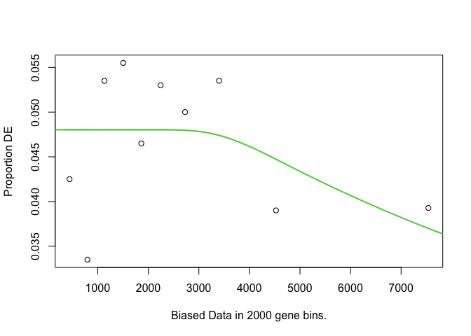

Then use `goseq()` function to perform the test:

```r
tb1 = goseq(pwf, "hg19", "ensGene")
head(tb1)
```

```
##        category over_represented_pvalue under_represented_pvalue numDEInCat
## 3496 GO:0006955            3.744379e-64                        1        270
## 992  GO:0002376            1.740297e-56                        1        319
## 3493 GO:0006952            5.062323e-55                        1        231
## 6643 GO:0019814            6.998452e-49                        1         67
## 2612 GO:0005576            3.615382e-48                        1        392
## 4500 GO:0009605            1.166372e-44                        1        292
##      numInCat                          term ontology
## 3496     1696               immune response       BP
## 992      2448         immune system process       BP
## 3493     1430              defense response       BP
## 6643      131        immunoglobulin complex       CC
## 2612     3692          extracellular region       CC
## 4500     2409 response to external stimulus       BP
```

This time we keep the genes with p-values as `NA` (they are basically genes not expressed).

```r
tb = read.table("E-GEOD-101794-analytics.tsv", sep = "\t", skip = 1)
tb = tb[, c(1, 3)]
colnames(tb) = c("gene", "p.value")
tb$fdr = p.adjust(tb$p.value, "BH")
genes = ifelse(tb$fdr < 0.05, 1, 0)
genes[is.na(genes)] = 0
names(genes) = tb$gene
table(genes)
```

```
## genes
##     0     1
## 64211  1006
```

```r
pwf = nullp(genes, "hg19", "ensGene")
```

```
## Loading hg19 length data...
```

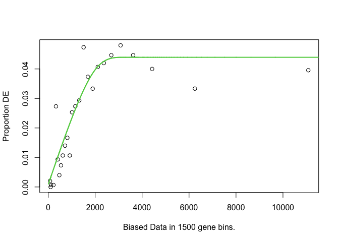

This becomes interesting. If include non-expressed genes, the bias becomes visible… Note we assume non-expressed genes are not differentially expressed.

So actually it means the bias comes from the p_expressed to gene length? This has to be studies with more details.

```r
tb2 = goseq(pwf, "hg19", "ensGene")
```

We compare `tb1` and `tb2`:

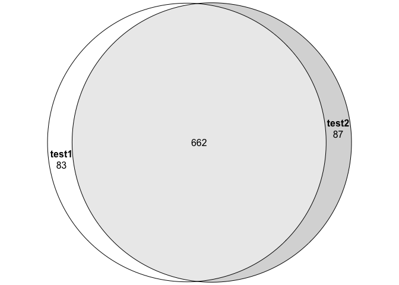

```r
library(eulerr)
lt = list(
    test1 = tb1$category[p.adjust(tb1$over_represented_pvalue, "BH") < 0.05],
    test2 = tb2$category[p.adjust(tb2$over_represented_pvalue, "BH") < 0.05]
)
plot(euler(lt), quantities = TRUE)
```

Does it mean the correction has no effect?

We also compare to ORA.

```r
tb = read.table("E-GEOD-101794-analytics.tsv", sep = "\t", skip = 1)
tb = tb[, c(2, 3)]
colnames(tb) = c("gene", "p.value")
tb$fdr = p.adjust(tb$p.value, "BH")
l = tb$fdr < 0.05; l[is.na(l)] = FALSE
diff_gene = tb$gene[l]
```

`diff_gene` are gene symbols. We convert them to Entrez IDs:

```r
convert_to_entrez_id = function(x) {
    if(is.matrix(x)) {
        map = cola:::guess_id_mapping(rownames(x))
        if(is.function(map)) {
            new_rn = map(rownames(x))
        } else {
            new_rn = map[rownames(x)]
        }
        l = is.na(new_rn)

        x = x[!l, , drop = FALSE]
        new_rn = new_rn[!l]

        x2 = do.call(rbind, tapply(1:nrow(x), new_rn, function(ind) {
            colMeans(x[ind, , drop = FALSE])
        }))
        return(x2)

    } else if(is.numeric(x)) {
        map = cola:::guess_id_mapping(names(x))
        x2 = s
        if(is.function(map)) {
            names(x2) = map(names(x))
        } else {
            names(x2) = map[names(x)]
        }
        x2 = x2[!is.na(names(x2))]
        x2 = tapply(x2, names(x2), mean)
        return(x2)
    } else {
        map = cola:::guess_id_mapping(x)
        if(is.function(map)) {
            x2 = map(x)
        } else {
            x2 = map[x]
        }
        x2 = x2[!is.na(x2)]
        x2 = unique(x2)
        return(x2)
    }
}
diff_gene = convert_to_entrez_id(diff_gene)
```

```
## testing org.Hs.egENSEMBL...
## testing org.Hs.egREFSEQ...
## testing org.Hs.egSYMBOL...
##   gene id might be SYMBOL (p = 0.950)
```

We use **clusterProfiler** to perform ORA analysis:

```r
library(clusterProfiler)
library(org.Hs.eg.db)
tb3 = enrichGO(gene = diff_gene, ont = "BP", OrgDb = org.Hs.eg.db)
```

Now we compare ORA to GOseq results. Note `tb1` and `tb2` contains results for all three ontologies (BP, CC, MF). Here we only need BP.

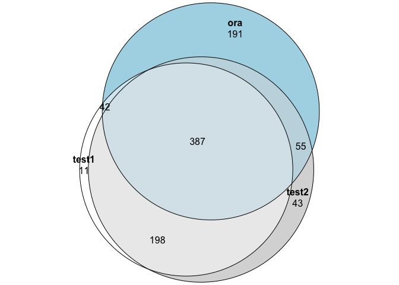

```r
tb1 = tb1[tb1$ontology == "BP", ]
tb2 = tb2[tb2$ontology == "BP", ]

library(eulerr)
lt = list(
    test1 = tb1$category[p.adjust(tb1$over_represented_pvalue, "BH") < 0.05],
    test2 = tb2$category[p.adjust(tb2$over_represented_pvalue, "BH") < 0.05],
    ora = tb3$ID[p.adjust(tb3$pvalue, "BH") < 0.05]
)
plot(euler(lt), quantities = TRUE)
```

Please note the difference may also come from the different implementation of the tools (e.g. GO versions, precessings), while not the methods selves.